# Kristin Jacobs Coral Aquatic Preserve

SEACAR Habitat Analyses

Last compiled on 10 June, 2026

# Funding & Acknowledgements

The data used in this analysis is from the Export Standardized Tables in the SEACAR Data Discovery Interface (DDI). Documents and information available through the SEACAR DDI are owned by the data provider(s) and users are expected to provide appropriate credit following accepted citation formats. Users are encouraged to access data to maximize utilization of gained knowledge, reducing redundant research and facilitating partnerships and scientific innovation.

With respect to documents and information available from SEACAR DDI, neither the State of Florida nor the Florida Department of Environmental Protection makes any warranty, expressed or implied, including the warranties of merchantability and fitness for a particular purpose arising out of the use or inability to use the data, or assumes any legal liability or responsibility for the accuracy, completeness, or usefulness of any information, apparatus, product, or process disclosed, or represents that its use would not infringe privately owned rights.

This report was funded in part, through a grant agreement from the Florida Department of Environmental Protection, Florida Coastal Management Program, by a grant provided by the Office for Coastal Management under the Coastal Zone Management Act of 1972, as amended, National Oceanic and Atmospheric Administration. The views, statements, findings, conclusions and recommendations expressed herein are those of the author(s) and do not necessarily reflect the views of the State of Florida, NOAA or any of their sub agencies.

**Published**: 2026-06-10

[figure not shown]

# Threshold Filtering

Threshold filters, following the guidance of Florida Department of Environmental Protection’s (*FDEP*) Division of Environmental Assessment and Restoration (*DEAR*) are used to exclude specific results values from the SEACAR Analysis. Based on the threshold filters, Quality Assurance / Quality Control (*QAQC*) Flags are inserted into the *SEACAR_QAQCFlagCode* and *SEACAR_QAQC_Description* columns of the export data. The *Include* column indicates whether the *QAQC* Flag will also indicate that data are excluded from analysis. No data are excluded from the data export, but the analysis scripts can use the *Include* column to exclude data (1 to include, 0 to exclude).

Continuous Water Quality threshold values

| *Parameter Name* | *Units* | *Low Threshold* | *High Threshold* |
| --- | --- | --- | --- |
| Chlorophyll a, Uncorrected for Pheophytin | ug/L | - | - |
| Dissolved Oxygen | mg/L | -0.000001 | 50 |
| Dissolved Oxygen Saturation | % | -0.000001 | 500 |
| Fluorescent Dissolved Organic Matter | QSE | - | - |
| Salinity | ppt | -0.000001 | 70 |
| Specific Conductivity | mS/cm | -0.000001 | 200 |
| Turbidity | NTU | -0.000001 | 4000 |
| Water Temperature | Degrees C | -5.000000 | 45 |
| pH | None | 2.000000 | 14 |

Discrete Water Quality threshold values

| *Parameter Name* | *Units* | *Low Threshold* | *High Threshold* |
| --- | --- | --- | --- |
| Ammonia, Un-ionized (NH3) | mg/L | - | - |
| Ammonium (NH4) | mg/L | - | - |
| Chlorophyll a, Corrected for Pheophytin | ug/L | - | - |
| Chlorophyll a, Uncorrected for Pheophytin | ug/L | - | - |
| Colored Dissolved Organic Matter | PCU | - | - |
| Dissolved Oxygen | mg/L | -0.000001 | 25 |
| Dissolved Oxygen Saturation | % | -0.000001 | 310 |
| Fluorescent Dissolved Organic Matter | QSE | - | - |
| Light Extinction Coefficient | m^-1 | - | - |
| NO2+3, Filtered | mg/L | - | - |
| Nitrate (NO3) | mg/L | - | - |
| Nitrite (NO2) | mg/L | - | - |
| Nitrogen, inorganic | mg/L | - | - |
| Nitrogen, organic | mg/L | - | - |
| Phosphate, Filtered (PO4) | mg/L | - | - |
| Salinity | ppt | -0.000001 | 70 |
| Secchi Depth | m | 0.000001 | 50 |
| Specific Conductivity | mS/cm | 0.005000 | 100 |
| Total Ammonia (N) | mg/L | - | - |
| Total Kjeldahl Nitrogen | mg/L | - | - |
| Total Nitrogen | mg/L | - | - |
| Total Nitrogen | mg/L | - | - |
| Total Phosphorus | mg/L | - | - |
| Total Suspended Solids | mg/L | - | - |
| Turbidity | NTU | - | - |
| Water Temperature | Degrees C | 3.000000 | 40 |
| pH | None | 2.000000 | 13 |

Quality Assurance Flags inserted based on threshold checks listed in Table 1 and 2

| *SEACAR QAQC Description* | *Include* | *SEACAR QAQCFlagCode* |
| --- | --- | --- |
| Exceeds maximum threshold | 0 | 2Q |
| Below minimum threshold | 0 | 4Q |
| Within threshold tolerance | 1 | 6Q |
| No defined thresholds for this parameter | 1 | 7Q |

# Value Qualifiers

Value qualifier codes included within the data are used to exclude certain results from the analysis. The data are retained in the data export files, but the analysis uses the *Include* column to filter the results.

**STORET and WIN value qualifier codes**

Value qualifier codes from *STORET* and *WIN* data are examined with the database and used to populate the *Include* column in data exports.

Value Qualifier codes excluded from analysis

| *Qualifier Source* | *Value Qualifier* | *Include* | *MDL* | *Description* |
| --- | --- | --- | --- | --- |
| STORET-WIN | H | 0 | 0 | Value based on field kit determination; results may not be accurate |
| STORET-WIN | J | 0 | 0 | Estimated value |
| STORET-WIN | V | 0 | 0 | Analyte was detected at or above method detection limit |
| STORET-WIN | Y | 0 | 0 | Lab analysis from an improperly preserved sample; data may be inaccurate |

**Discrete Water Quality Value Qualifiers**

The following value qualifiers are highlighted in the Discrete Water Quality section of this report. An exception is made for **Program 476** - *Charlotte Harbor Estuaries Volunteer Water Quality Monitoring Network* and data flagged with Value Qualifier **H** are included for this program only.

**H** - Value based on field kit determiniation; results may not be accurate. This code shall be used if a field screening test (e.g., field gas chromatograph data, immunoassay, or vendor-supplied field kit) was used to generate the value and the field kit or method has not been recognized by the Department as equivalent to laboratory methods.

**I** - The reported value is greater than or equal to the laboratory method detection limit but less than the laboratory practical quantitation limit.

**Q** - Sample held beyond the accepted holding time. This code shall be used if the value is derived from a sample that was prepared or analyzed after the approved holding time restrictions for sample preparation or analysis.

**S** - Secchi disk visible to bottom of waterbody. The value reported is the depth of the waterbody at the location of the Secchi disk measurement.

**U** - Indicates that the compound was analyzed for but not detected. This symbol shall be used to indicate that the specified component was not detected. The value associated with the qualifier shall be the laboratory method detection limit. Unless requested by the client, less than the method detection limit values shall not be reported

**Systemwide Monitoring Program (SWMP) value qualifier codes**

Value qualifier codes from the *SWMP* continuous program are examined with the database and used to populate the *Include* column in data exports. *SWMP* Qualifier Codes are indicated by *QualifierSource=SWMP*.

SWMP Value Qualifier codes

| *Qualifier Source* | *Value Qualifier* | *Include* | *Description* |
| --- | --- | --- | --- |
| SWMP | -1 | 1 | Optional parameter not collected |
| SWMP | -2 | 0 | Missing data |
| SWMP | -3 | 0 | Data rejected due to QA/QC |
| SWMP | -4 | 0 | Outside low sensor range |
| SWMP | -5 | 0 | Outside high sensor range |
| SWMP | 0 | 1 | Passed initial QA/QC checks |
| SWMP | 1 | 0 | Suspect data |
| SWMP | 2 | 1 | Reserved for future use |
| SWMP | 3 | 1 | Calculated data: non-vented depth/level sensorcorrection for changes in barometric pressure |
| SWMP | 4 | 1 | Historical: Pre-auto QA/QC |
| SWMP | 5 | 1 | Corrected data |

# Water Column

The water column habitat extends from the water’s surface to the bottom sediments, and it’s where fish, dolphins, crabs and people swim! So much life makes its home in the water column that the health of marine and coastal ecosystems, as well as human economies, depend on the condition of this vulnerable habitat. Local patterns of rainfall, temperature, winds and currents can rapidly change the condition of the water column, while global influences such as [El Niño/La Niña](https://oceanservice.noaa.gov/facts/ninonina.html), large-scale fluctuation in sea temperatures and climate change can have long-term effects. Inputs from the prosperity of our day-to-day lives including farming, mining and forestry, and emissions from power generation, automobiles and water treatment can also alter the health of the water column. Acting alone or together, each input can have complex and lasting effects on habitats and ecosystems.

SEACAR evaluates water column health with several essential parameters. These include nutrient surveys of nitrogen and phosphorus, and water quality assessments of salinity, dissolved oxygen, pH, and water temperature. Water clarity is evaluated with Secchi depth, turbidity, levels of chlorophyll a, total suspended solids, and colored dissolved organic matter. Additionally, the richness of nekton is indicated by the abundance of free-swimming fishes and macroinvertebrates like crabs and shrimps.

# Seasonal Kendall-Tau Analysis

Indicators must have a minimum of five to ten years, depending on the habitat, of data within the geographic range of the analysis to be included in the analysis. Ten years of data are required for discrete parameters, and five years of data are required for continuous parameters. If there are insufficient years of data, the number of years of data available will be noted and labeled as “insufficient data to conduct analysis”. Further, for the preferred Seasonal Kendall-Tau test, there must be data from at least two months in common across at least two consecutive years within the RCP managed area being analyzed. Values that pass both of these tests will be included in the analysis and be labeled as *Use_In_Analysis* = **TRUE**. Any that fail either test will be excluded from the analyses and labeled as *Use_In_Analysis* = **FALSE**. The points for all Water Column plots displayed in this section are monthly averages. Trend significance will be denoted as “Significant Trend” (when p < 0.05), or “Non-significant Trend” (when p >= 0.05). Any parameters with insufficient data to perform Seasonal Kendall-Tau test will have their monthly averages plotted without a corresponding trend line.

# Water Quality - Discrete

The following files were used in the discrete analysis:

- *Combined_WQ_WC_NUT_Chlorophyll_a_corrected_for_pheophytin-2026-May-18.txt*
- *Combined_WQ_WC_NUT_Chlorophyll_a_uncorrected_for_pheophytin-2026-May-18.txt*
- *Combined_WQ_WC_NUT_Colored_dissolved_organic_matter_CDOM-2026-May-18.txt*
- *Combined_WQ_WC_NUT_Dissolved_Oxygen-2026-May-18.txt*
- *Combined_WQ_WC_NUT_Dissolved_Oxygen_Saturation-2026-May-18.txt*
- *Combined_WQ_WC_NUT_pH-2026-May-18.txt*
- *Combined_WQ_WC_NUT_Salinity-2026-May-18.txt*
- *Combined_WQ_WC_NUT_Secchi_Depth-2026-May-18.txt*
- *Combined_WQ_WC_NUT_Total_Nitrogen-2026-May-18.txt*
- *Combined_WQ_WC_NUT_Total_Phosphorus-2026-May-18.txt*
- *Combined_WQ_WC_NUT_Total_Suspended_Solids_TSS-2026-May-18.txt*
- *Combined_WQ_WC_NUT_Turbidity-2026-May-18.txt*
- *Combined_WQ_WC_NUT_Water_Temperature-2026-May-18.txt*

## Dissolved Oxygen - Discrete

**Seasonal Kendall-Tau Trend Analysis**

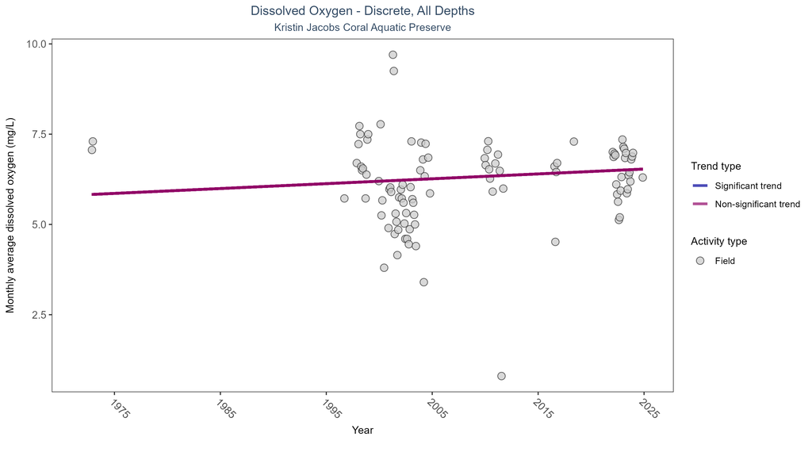

Scatter plot of monthly average dissolved oxygen over time. If the time series included ten or more years of discrete observations, a significant (blue) or non-significant (magenta) trend line is also shown. Only dissolved oxygen values measured in the field (circles) are included in the plot.

Seasonal Kendall-Tau Trend Analysis for Dissolved Oxygen

| Activity Type | Statistical Trend | No. of Samples | No. Years with Data | Period of Record | Median Result Value | Tau | Sen Intercept | Sen Slope | P |
| --- | --- | --- | --- | --- | --- | --- | --- | --- | --- |
| Field | No detectable trend | 715 | 18 | 1972 - 2024 | 6.5 | 0.1059 | 5.8188 | 0.0135 | 0.3679 |

Dissolved oxygen showed no detectable trend between 1972 and 2024.

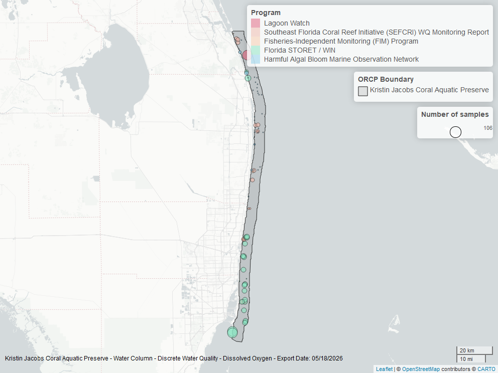

Map showing location of discrete water quality sampling locations within the boundaries of *Kristin Jacobs Coral Aquatic Preserve*. The bubble size on the maps above reflect the amount of data available at each sampling site.

Programs contributing data for Dissolved Oxygen

| ProgramID | N_Data | YearMin | YearMax |
| --- | --- | --- | --- |
| 5002 | 786 | 1996 | 2023 |
| 5058 | 266 | 2009 | 2011 |
| 3001 | 98 | 1999 | 2003 |
| 95 | 69 | 1972 | 2018 |
| 69 | 5 | 1998 | 2024 |

**Program names:**

*5002* - Florida STORET / WIN<sup>1</sup>  
*5058* - Southeast Florida Coral Reef Initiative (SEFCRI) Water Quality Monitoring Report<sup>2</sup>  
*3001* - Lagoon Watch<sup>3</sup>  
*95* - Harmful Algal Bloom Marine Observation Network<sup>4</sup>  
*69* - Fisheries-Independent Monitoring (FIM) Program<sup>5</sup>

## Dissolved Oxygen Saturation - Discrete

**Seasonal Kendall-Tau Trend Analysis**

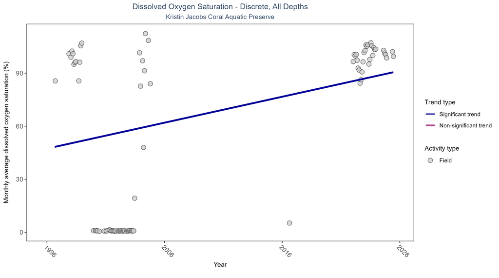

Scatter plot of monthly average dissolved oxygen saturation over time. If the time series included ten or more years of discrete observations, a significant (blue) or non-significant (magenta) trend line is also shown. Only dissolved oxygen saturation values measured in the field (circles) are included in the plot.

Seasonal Kendall-Tau Trend Analysis for Dissolved Oxygen Saturation

| Activity Type | Statistical Trend | No. of Samples | No. Years with Data | Period of Record | Median Result Value | Tau | Sen Intercept | Sen Slope | P |
| --- | --- | --- | --- | --- | --- | --- | --- | --- | --- |
| Field | Increasing trend | 1418 | 14 | 1996 - 2025 | 101.5 | 0.3764 | 47.3187 | 1.4668 | 0.0001 |

Monthly average dissolved oxygen saturation increased by 1.47% per year.

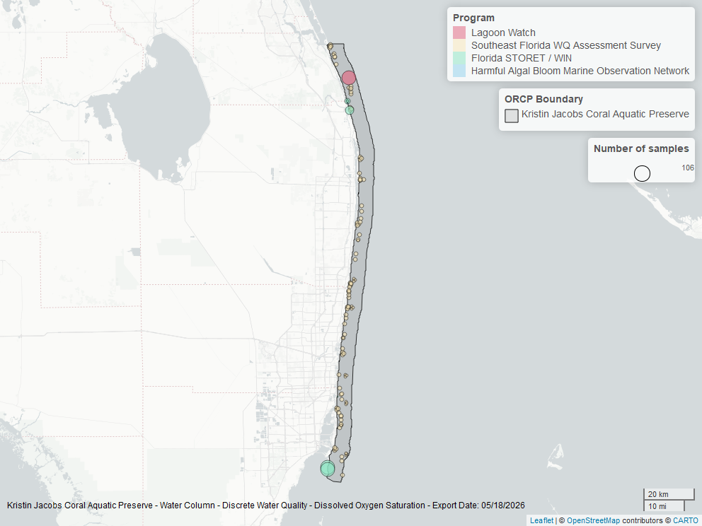

Map showing location of discrete water quality sampling locations within the boundaries of *Kristin Jacobs Coral Aquatic Preserve*. The bubble size on the maps above reflect the amount of data available at each sampling site.

Programs contributing data for Dissolved Oxygen Saturation

| ProgramID | N_Data | YearMin | YearMax |
| --- | --- | --- | --- |
| 5033 | 1042 | 2024 | 2025 |
| 5002 | 277 | 1996 | 2023 |
| 3001 | 98 | 1999 | 2003 |
| 95 | 1 | 2016 | 2016 |

**Program names:**

*5033* - Southeast Florida Water Quality Assessment Survey<sup>6</sup>  
*5002* - Florida STORET / WIN<sup>1</sup>  
*3001* - Lagoon Watch<sup>3</sup>  
*95* - Harmful Algal Bloom Marine Observation Network<sup>4</sup>

## pH - Discrete

**Seasonal Kendall-Tau Trend Analysis**

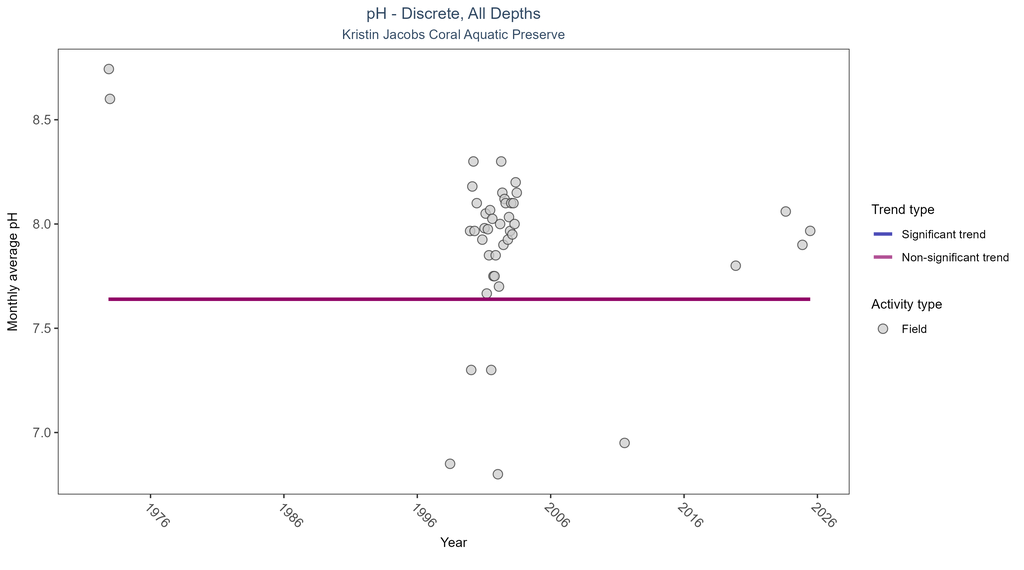

Scatter plot of monthly average pH over time. If the time series included ten or more years of discrete observations, a significant (blue) or non-significant (magenta) trend line is also shown. Only pH values measured in the field (circles) are included in the plot.

Seasonal Kendall-Tau Trend Analysis for pH

| Activity Type | Statistical Trend | No. of Samples | No. Years with Data | Period of Record | Median Result Value | Tau | Sen Intercept | Sen Slope | P |
| --- | --- | --- | --- | --- | --- | --- | --- | --- | --- |
| Field | No detectable trend | 376 | 12 | 1972 - 2025 | 7.99 | 0.0651 | 7.6392 | 0 | 1 |

pH showed no detectable trend between 1972 and 2025.

[figure not shown]

Map showing location of discrete water quality sampling locations within the boundaries of *Kristin Jacobs Coral Aquatic Preserve*. The bubble size on the maps above reflect the amount of data available at each sampling site.

Programs contributing data for pH

| ProgramID | N_Data | YearMin | YearMax |
| --- | --- | --- | --- |
| 5033 | 204 | 2025 | 2025 |
| 3001 | 103 | 1999 | 2003 |
| 95 | 62 | 1972 | 1972 |
| 69 | 7 | 1998 | 2024 |
| 5002 | 2 | 2011 | 2023 |

**Program names:**

*5033* - Southeast Florida Water Quality Assessment Survey<sup>6</sup>  
*3001* - Lagoon Watch<sup>3</sup>  
*95* - Harmful Algal Bloom Marine Observation Network<sup>4</sup>  
*69* - Fisheries-Independent Monitoring (FIM) Program<sup>5</sup>  
*5002* - Florida STORET / WIN<sup>1</sup>

## Salinity - Discrete

**Seasonal Kendall-Tau Trend Analysis**

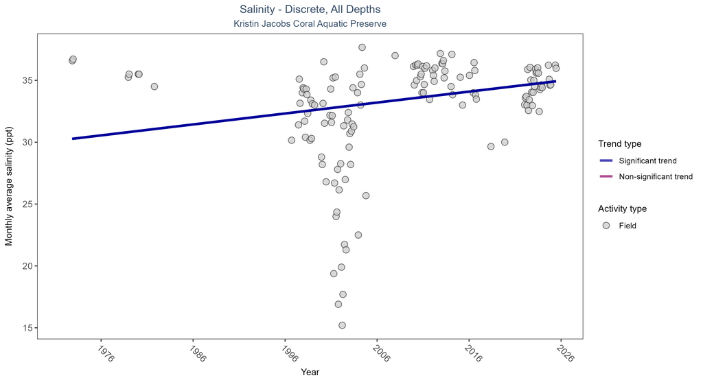

Scatter plot of monthly average salinity over time. If the time series included ten or more years of discrete observations, significant (blue) or non-significant (magenta) trend lines are also shown. Discrete salinity values derived from grab samples analyzed in the field (circles) or the laboratory (triangles) are both included in the plot.

Seasonal Kendall-Tau Trend Analysis for Salinity

| Activity Type | Statistical Trend | No. of Samples | No. Years with Data | Period of Record | Median Result Value | Tau | Sen Intercept | Sen Slope | P |
| --- | --- | --- | --- | --- | --- | --- | --- | --- | --- |
| All | Increasing trend | 1895 | 29 | 1972 - 2025 | 36 | 0.2628 | 30.198 | 0.0884 | 0.0003 |

Monthly average salinity increased by 0.09 ppt per year.

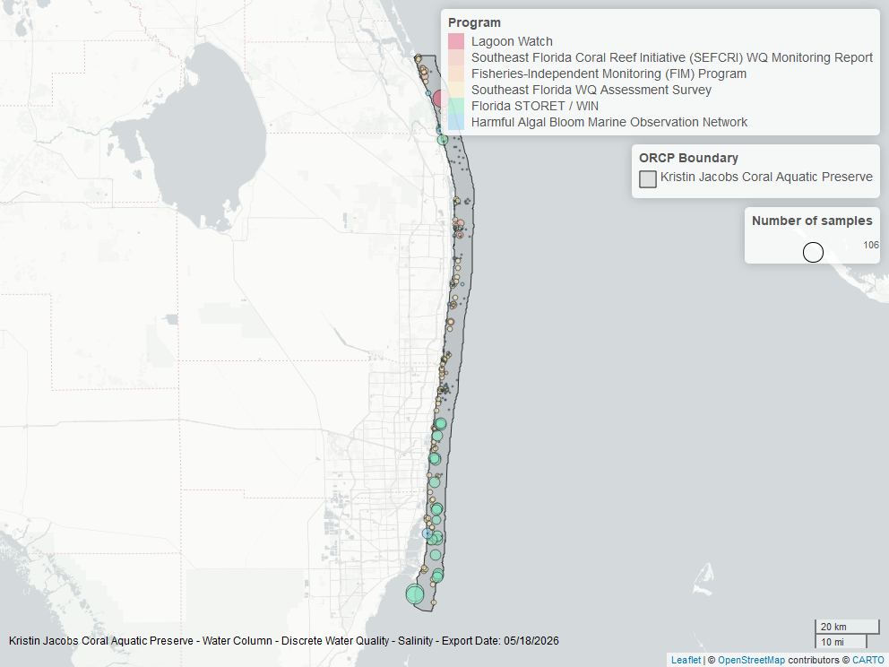

Map showing location of discrete water quality sampling locations within the boundaries of *Kristin Jacobs Coral Aquatic Preserve*. The bubble size on the maps above reflect the amount of data available at each sampling site.

Programs contributing data for Salinity

| ProgramID | N_Data | YearMin | YearMax |
| --- | --- | --- | --- |
| 5033 | 1042 | 2024 | 2025 |
| 5002 | 899 | 1996 | 2023 |
| 5058 | 266 | 2009 | 2011 |
| 95 | 199 | 1972 | 2018 |
| 3001 | 102 | 1999 | 2003 |
| 69 | 11 | 1997 | 2024 |

**Program names:**

*5033* - Southeast Florida Water Quality Assessment Survey<sup>6</sup>  
*5002* - Florida STORET / WIN<sup>1</sup>  
*5058* - Southeast Florida Coral Reef Initiative (SEFCRI) Water Quality Monitoring Report<sup>2</sup>  
*95* - Harmful Algal Bloom Marine Observation Network<sup>4</sup>  
*3001* - Lagoon Watch<sup>3</sup>  
*69* - Fisheries-Independent Monitoring (FIM) Program<sup>5</sup>

## Total Phosphorus - Discrete

**Seasonal Kendall-Tau Trend Analysis**

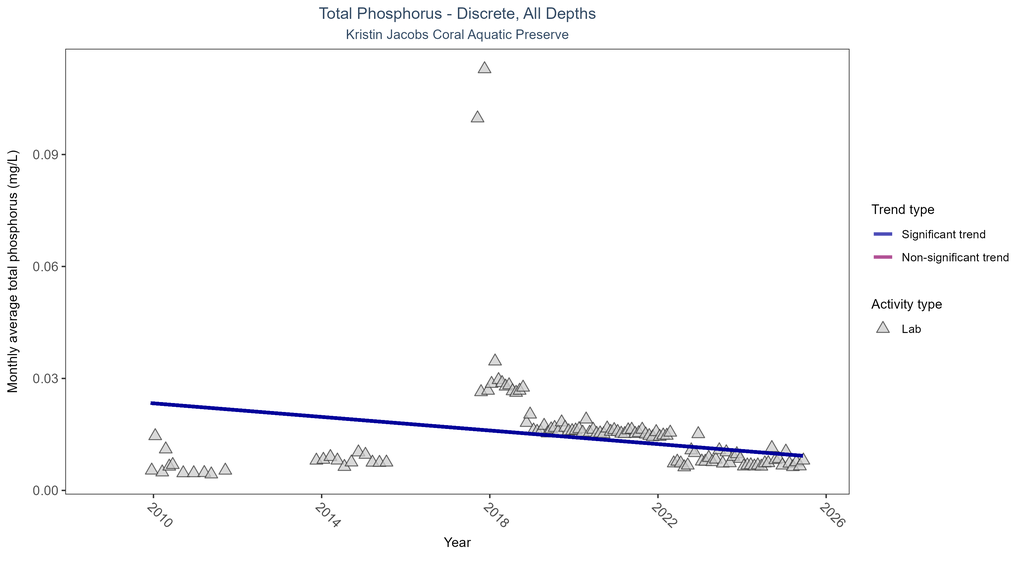

Scatter plot of monthly average total phosphorus over time. If the time series included ten or more years of discrete observations, a significant (blue) or non-significant (magenta) trend line is also shown. Only phosphorus values obtained from laboratory analyses (triangles) are included in the plot.

Seasonal Kendall-Tau Trend Analysis for Total Phosphorus

| Activity Type | Statistical Trend | No. of Samples | No. Years with Data | Period of Record | Median Result Value | Tau | Sen Intercept | Sen Slope | P |
| --- | --- | --- | --- | --- | --- | --- | --- | --- | --- |
| Lab | Decreasing trend | 17904 | 15 | 2009 - 2025 | 0.014 | -0.3362 | 0.0242 | -0.0009 | 0.0001 |

Monthly average total phosphorus decreased by less than 0.01 mg/L per year.

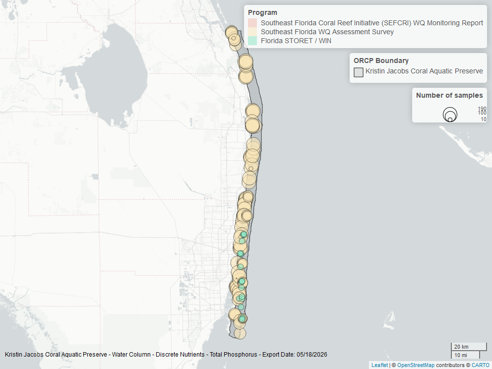

Map showing location of discrete water quality sampling locations within the boundaries of *Kristin Jacobs Coral Aquatic Preserve*. The bubble size on the maps above reflect the amount of data available at each sampling site.

Programs contributing data for Total Phosphorus

| ProgramID | N_Data | YearMin | YearMax |
| --- | --- | --- | --- |
| 5033 | 17934 | 2017 | 2025 |
| 5002 | 642 | 2013 | 2023 |
| 5058 | 268 | 2009 | 2011 |

**Program names:**

*5033* - Southeast Florida Water Quality Assessment Survey<sup>6</sup>  
*5002* - Florida STORET / WIN<sup>1</sup>  
*5058* - Southeast Florida Coral Reef Initiative (SEFCRI) Water Quality Monitoring Report<sup>2</sup>

## Turbidity - Discrete

**Seasonal Kendall-Tau Trend Analysis**

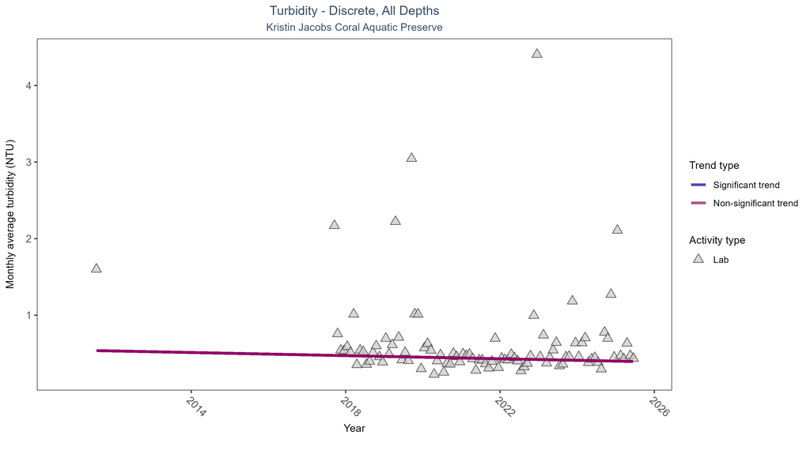

Scatter plot of monthly average turbidity over time. If the time series included ten or more years of discrete observations, a significant (blue) or non-significant (magenta) trend line is also shown. Only turbidity values measured in the laboratory (triangles) are included in the plot.

Seasonal Kendall-Tau Trend Analysis for Turbidity

| Activity Type | Statistical Trend | No. of Samples | No. Years with Data | Period of Record | Median Result Value | Tau | Sen Intercept | Sen Slope | P |
| --- | --- | --- | --- | --- | --- | --- | --- | --- | --- |
| Lab | No detectable trend | 18027 | 10 | 2011 - 2025 | 0.3 | -0.1138 | 0.5434 | -0.0102 | 0.2184 |

Turbidity showed no detectable trend between 2011 and 2025.

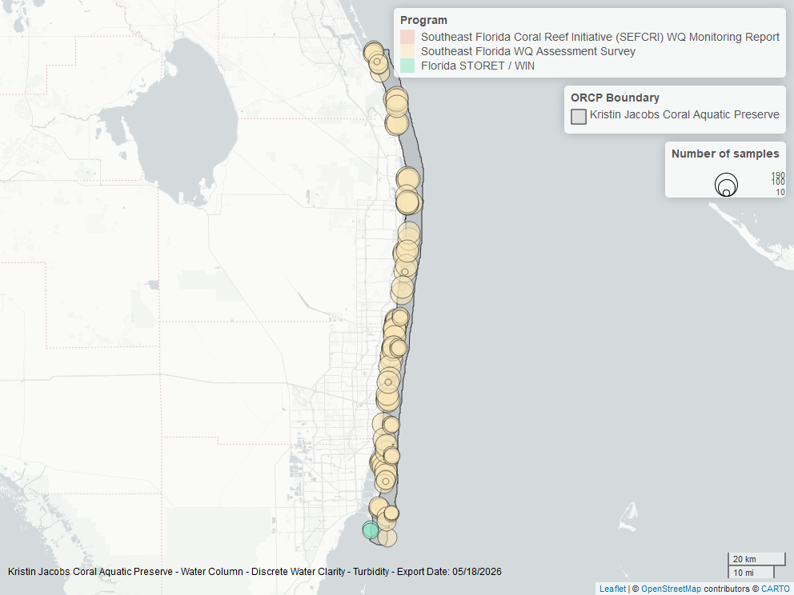

Map showing location of discrete water quality sampling locations within the boundaries of *Kristin Jacobs Coral Aquatic Preserve*. The bubble size on the maps above reflect the amount of data available at each sampling site.

Programs contributing data for Turbidity

| ProgramID | N_Data | YearMin | YearMax |
| --- | --- | --- | --- |
| 5033 | 18051 | 2017 | 2025 |
| 5058 | 264 | 2009 | 2011 |
| 5002 | 210 | 2011 | 2023 |

**Program names:**

*5033* - Southeast Florida Water Quality Assessment Survey<sup>6</sup>  
*5058* - Southeast Florida Coral Reef Initiative (SEFCRI) Water Quality Monitoring Report<sup>2</sup>  
*5002* - Florida STORET / WIN<sup>1</sup>

## Water Temperature - Discrete

**Seasonal Kendall-Tau Trend Analysis**

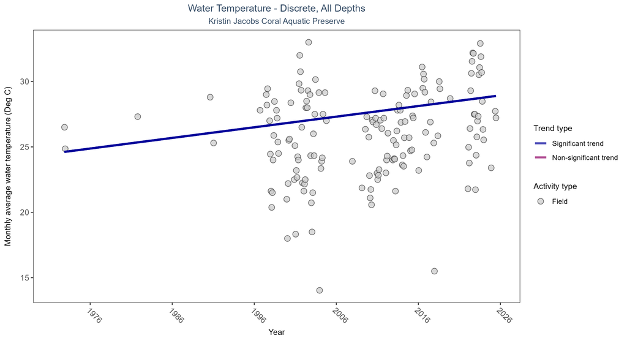

Scatter plot of monthly average water temperature over time. If the time series included ten or more years of discrete observations, a significant (blue) or non-significant (magenta) trend line is also shown. Only water temperature measurements taken in the field (circles) are included in the plot.

Seasonal Kendall-Tau Trend Analysis for Water Temperature

| Activity Type | Statistical Trend | No. of Samples | No. Years with Data | Period of Record | Median Result Value | Tau | Sen Intercept | Sen Slope | P |
| --- | --- | --- | --- | --- | --- | --- | --- | --- | --- |
| Field | Increasing trend | 1928 | 29 | 1972 - 2025 | 27 | 0.2868 | 24.5503 | 0.0813 | 0 |

Monthly average water temperature increased by 0.08°C per year.

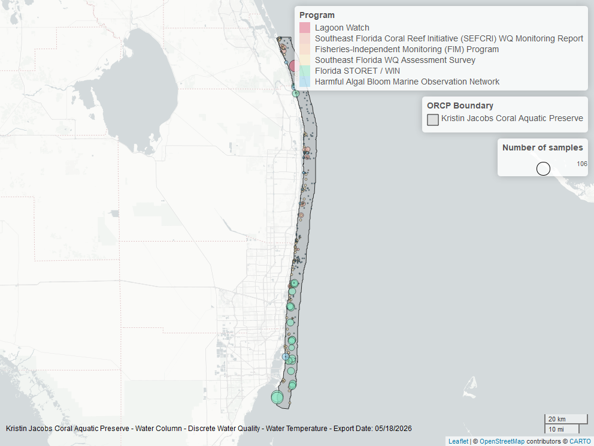

Map showing location of discrete water quality sampling locations within the boundaries of *Kristin Jacobs Coral Aquatic Preserve*. The bubble size on the maps above reflect the amount of data available at each sampling site.

Programs contributing data for Water Temperature

| ProgramID | N_Data | YearMin | YearMax |
| --- | --- | --- | --- |
| 5002 | 903 | 1996 | 2023 |
| 5033 | 408 | 2025 | 2025 |
| 5058 | 266 | 2009 | 2011 |
| 95 | 239 | 1972 | 2018 |
| 3001 | 104 | 1999 | 2003 |
| 69 | 11 | 1997 | 2024 |

**Program names:**

*5002* - Florida STORET / WIN<sup>1</sup>  
*5033* - Southeast Florida Water Quality Assessment Survey<sup>6</sup>  
*5058* - Southeast Florida Coral Reef Initiative (SEFCRI) Water Quality Monitoring Report<sup>2</sup>  
*95* - Harmful Algal Bloom Marine Observation Network<sup>4</sup>  
*3001* - Lagoon Watch<sup>3</sup>  
*69* - Fisheries-Independent Monitoring (FIM) Program<sup>5</sup>

# Water Quality - Continuous

The following files were used in the continuous analysis:

- *Combined_WQ_WC_NUT_cont_Chlorophyll_a_Uncorrected_for_Pheophytin-2026-Mar-06.txt*
- *Combined_WQ_WC_NUT_cont_Dissolved_Oxygen-2026-Mar-06.txt*
- *Combined_WQ_WC_NUT_cont_Dissolved_Oxygen_Saturation-2026-Mar-06.txt*
- *Combined_WQ_WC_NUT_cont_Fluorescent_Dissolved_Organic_Matter-2026-Mar-06.txt*
- *Combined_WQ_WC_NUT_cont_pH-2026-Mar-06.txt*
- *Combined_WQ_WC_NUT_cont_Salinity-2026-Mar-06.txt*
- *Combined_WQ_WC_NUT_cont_Specific_Conductivity-2026-Mar-06.txt*
- *Combined_WQ_WC_NUT_cont_Turbidity-2026-Mar-06.txt*
- *Combined_WQ_WC_NUT_cont_Water_Temperature-2026-Mar-06.txt*

**Continuous monitoring locations in Kristin Jacobs Coral Aquatic Preserve**

Station overview for Continuous parameters by Program

| ProgramID | ProgramLocationID | Years of Data | Use in Analysis | Parameters |
| --- | --- | --- | --- | --- |
| 5 | LKWF1 | 42 | TRUE | Water Temperature |
| 986 | 1 | 11 | TRUE | Water Temperature |
| 986 | 2 | 11 | TRUE | Water Temperature |
| 986 | 3 | 11 | TRUE | Water Temperature |
| 986 | 4 | 11 | TRUE | Water Temperature |
| 986 | 5 | 11 | TRUE | Water Temperature |
| 986 | 6 | 11 | TRUE | Water Temperature |
| 986 | 84 | 17 | TRUE | Water Temperature |
| 986 | 85 | 17 | TRUE | Water Temperature |
| 986 | 86 | 17 | TRUE | Water Temperature |
| 986 | 87 | 17 | TRUE | Water Temperature |
| 986 | 88 | 17 | TRUE | Water Temperature |
| 986 | 89 | 17 | TRUE | Water Temperature |
| 986 | 90 | 17 | TRUE | Water Temperature |
| 986 | 91 | 17 | TRUE | Water Temperature |
| 986 | 92 | 17 | TRUE | Water Temperature |
| 986 | 93 | 17 | TRUE | Water Temperature |
| 986 | 94 | 17 | TRUE | Water Temperature |
| 986 | 95 | 17 | TRUE | Water Temperature |
| 986 | 96 | 6 | TRUE | Water Temperature |
| 986 | 97 | 14 | TRUE | Water Temperature |
| 986 | 98 | 14 | TRUE | Water Temperature |

**Program names:**

*5* - National Data Buoy Center<sup>7</sup>  
*986* - Water Temperature on Coral Reefs in the Florida Keys<sup>8</sup>

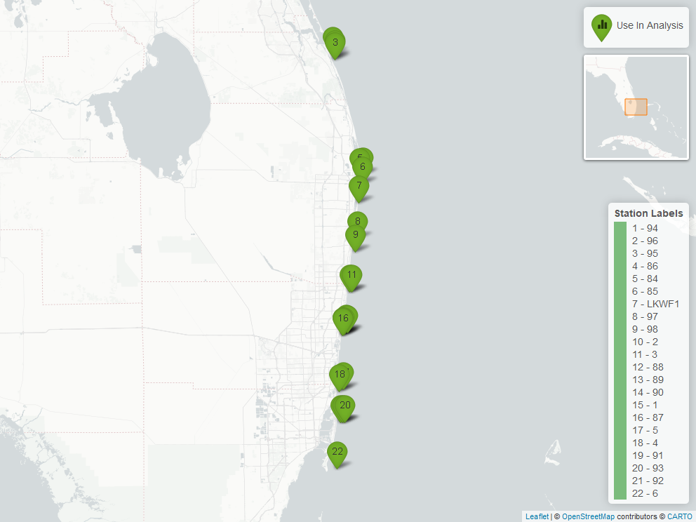

Map showing continuous water quality sampling locations within the boundaries of *Kristin Jacobs Coral Aquatic Preserve*. Sites marked as *Use In Analysis* (green) are featured in this report.

### Water Temperature - Continuous - Program 5

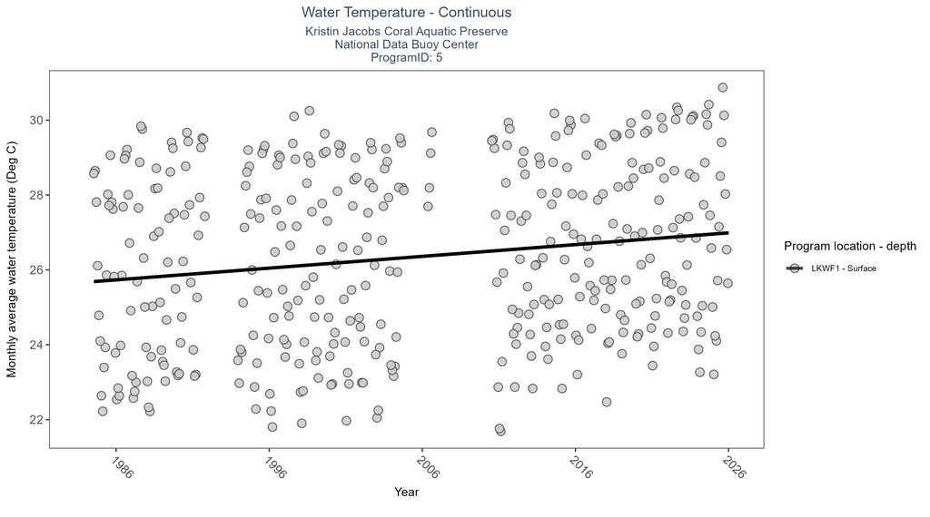

Scatter plot of monthly average water temperature over time at continuously monitored program locations. Each location is analyzed separately, with significant (blue) or non-significant (magenta) trend lines shown for time series that included five or more years of observations.

Seasonal Kendall-Tau Results for Water Temperature - Program 5

| Program Location | Statistical Trend | No. of Samples | No. Years with Data | Period of Record | Median Result Value | Tau | Sen Intercept | Sen Slope | P |
| --- | --- | --- | --- | --- | --- | --- | --- | --- | --- |
| LKWF1 | Significantly increasing trend | 1378722 | 37 | 1984 - 2025 | 26.5 | 0.43 | 25.67 | 0.03 | 0 |

### Water Temperature - Continuous - Program 986

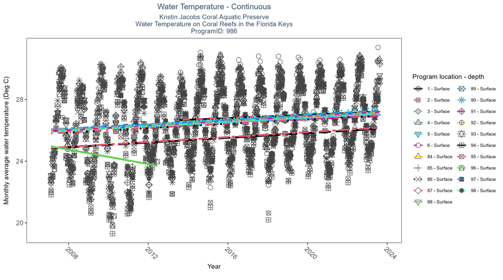

Scatter plot of monthly average water temperature over time at continuously monitored program locations. Each location is analyzed separately, with significant (blue) or non-significant (magenta) trend lines shown for time series that included five or more years of observations.

Seasonal Kendall-Tau Results for Water Temperature - Program 986

| Program Location | Statistical Trend | No. of Samples | No. Years with Data | Period of Record | Median Result Value | Tau | Sen Intercept | Sen Slope | P |
| --- | --- | --- | --- | --- | --- | --- | --- | --- | --- |
| 1 | Significantly increasing trend | 73700 | 11 | 2013 - 2023 | 26.50 | 0.23 | 26.62 | 0.06 | 0.00 |
| 2 | Significantly increasing trend | 68589 | 11 | 2013 - 2023 | 26.74 | 0.32 | 26.65 | 0.06 | 0.00 |
| 3 | Significantly increasing trend | 69054 | 11 | 2013 - 2023 | 26.69 | 0.32 | 26.51 | 0.07 | 0.00 |
| 4 | Significantly increasing trend | 77960 | 11 | 2013 - 2023 | 26.69 | 0.28 | 26.36 | 0.06 | 0.00 |
| 5 | Significantly increasing trend | 60729 | 11 | 2013 - 2023 | 26.69 | 0.28 | 26.33 | 0.06 | 0.00 |
| 84 | Significantly increasing trend | 117729 | 17 | 2007 - 2023 | 26.37 | 0.40 | 25.91 | 0.07 | 0.00 |
| 85 | Significantly increasing trend | 118414 | 17 | 2007 - 2023 | 26.29 | 0.38 | 26.03 | 0.07 | 0.00 |
| 86 | Significantly increasing trend | 113127 | 17 | 2007 - 2023 | 26.20 | 0.39 | 25.80 | 0.07 | 0.00 |
| 87 | Significantly increasing trend | 117324 | 17 | 2007 - 2023 | 26.50 | 0.37 | 25.81 | 0.07 | 0.00 |
| 88 | Significantly increasing trend | 123687 | 17 | 2007 - 2023 | 26.42 | 0.38 | 25.97 | 0.07 | 0.00 |
| 89 | Significantly increasing trend | 120476 | 17 | 2007 - 2023 | 26.32 | 0.38 | 26.06 | 0.07 | 0.00 |
| 90 | Significantly increasing trend | 103477 | 17 | 2007 - 2023 | 26.48 | 0.39 | 25.91 | 0.07 | 0.00 |
| 91 | Significantly increasing trend | 111048 | 17 | 2007 - 2023 | 26.60 | 0.38 | 25.93 | 0.08 | 0.00 |
| 92 | Significantly increasing trend | 120189 | 17 | 2007 - 2023 | 26.50 | 0.40 | 25.90 | 0.08 | 0.00 |
| 93 | Significantly increasing trend | 115688 | 17 | 2007 - 2023 | 26.56 | 0.38 | 26.04 | 0.06 | 0.00 |
| 94 | Significantly increasing trend | 98419 | 17 | 2007 - 2023 | 25.62 | 0.34 | 24.82 | 0.08 | 0.00 |
| 95 | Significantly increasing trend | 109401 | 17 | 2007 - 2023 | 25.62 | 0.36 | 24.85 | 0.08 | 0.00 |
| 96 | No significant trend | 25550 | 6 | 2007 - 2012 | 24.87 | -0.25 | 24.98 | -0.23 | 0.08 |
| 97 | Significantly increasing trend | 105832 | 14 | 2010 - 2023 | 26.50 | 0.42 | 26.21 | 0.08 | 0.00 |
| 98 | Significantly increasing trend | 94894 | 14 | 2010 - 2023 | 26.45 | 0.42 | 26.18 | 0.09 | 0.00 |
| 6 | Significantly increasing trend | 69753 | 11 | 2013 - 2023 | 26.84 | 0.19 | 26.41 | 0.05 | 0.01 |

At twenty-one program locations, monthly average water temperature increased between 0.03 and 0.09°C per year. No detectable change in monthly average water temperature was observed at one location.

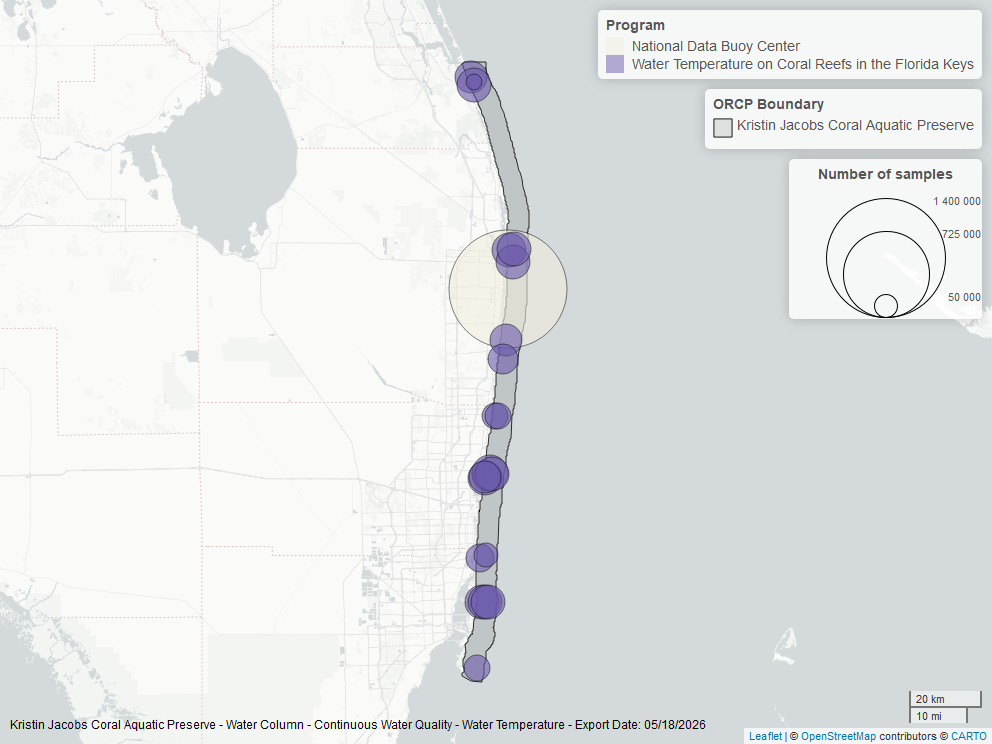

Map showing location of water temperature continuous water quality sampling locations within the boundaries of *Kristin Jacobs Coral Aquatic Preserve*. The bubble size on the maps above reflect the amount of data available at each sampling site.

# Coral Reef

The data file used is: **All_CORAL_Parameters-2026-Jun-04.txt**

**Percent Cover**

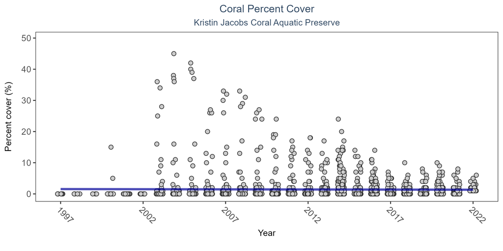

Scatter plot of live coral coverage over time as a percent of reef surface. Species groups include octocorals, milleporans, and scleractinians. If the time series included five or more years of observations, a significant (blue) or non-significant (magenta) trend line is also shown. Data points are jittered horizontally to reduce overlap.

Coral Percent Cover

| Statistical Trend | Period of Record | LME Intercept | LME Slope | p |
| --- | --- | --- | --- | --- |
| Decreasing trend | 1997 - 2022 | 18.27128 | -0.00837 | 0 |

Annual average percent cover decreased by -0.01% between 1997 and 2022.

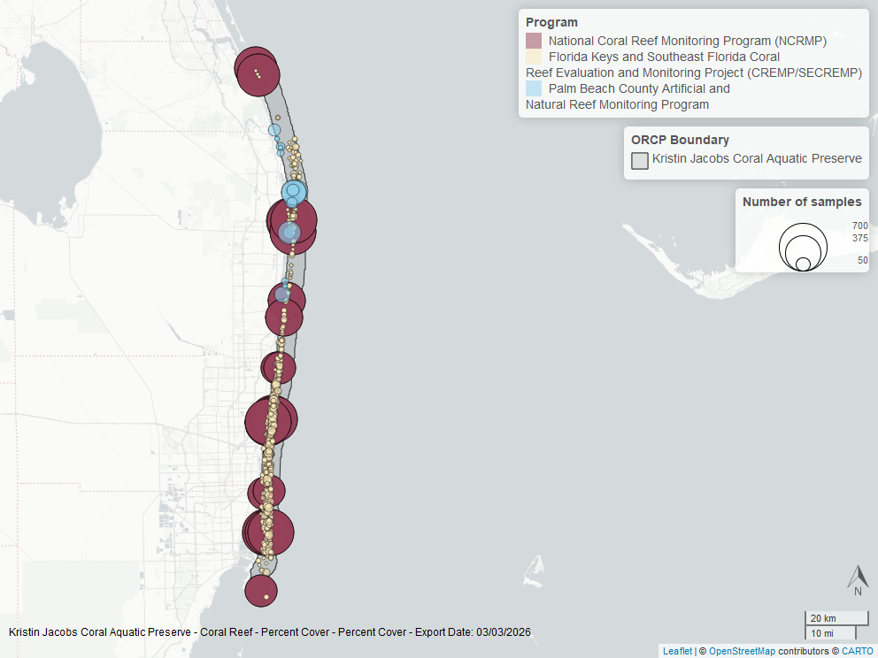

Map showing location of coral percent cover sampling locations within the boundaries of *Kristin Jacobs Coral Aquatic Preserve*. The bubble size on the maps above reflect the amount of data available at each sampling site.

**Species Richness**

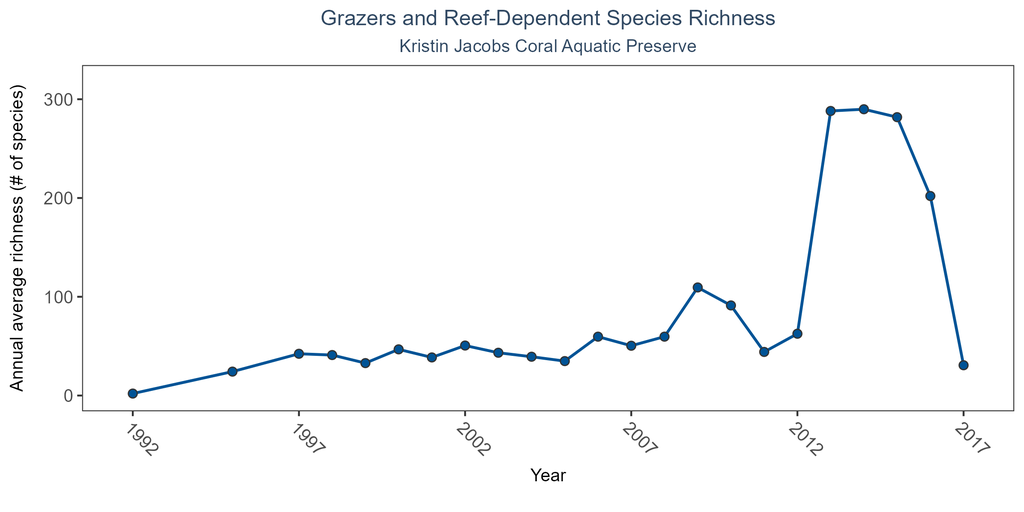

Line graph of annual average species richness of grazers and reef-dependent species over time. If the time series included more than one year of observations, a line connects the data points for visualization.

Coral Species Richness

| No. of Samples | No. Years with Data | Period of Record | Median No. of Taxa | Mean No. of Taxa |
| --- | --- | --- | --- | --- |
| 3269 | 23 | 1992 - 2017 | 294 | 218.4475 |

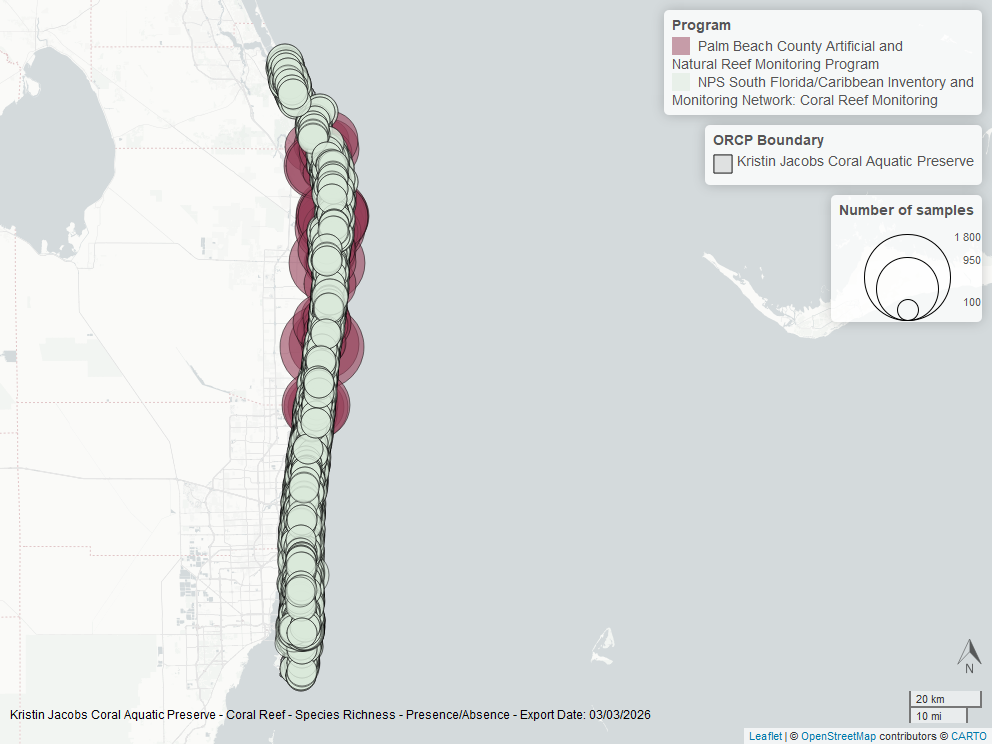

Map showing location of coral species richness sampling locations within the boundaries of *Kristin Jacobs Coral Aquatic Preserve*. The bubble size on the maps above reflect the amount of data available at each sampling site.

# Species list

| Abudefduf saxatilis<sup>1</sup> | Epinephelus itajara<sup>1</sup> | Opsanus tau<sup>1</sup> |
| --- | --- | --- |
| Abudefduf taurus<sup>1</sup> | Epinephelus morio<sup>1</sup> | Orbicella annularis<sup>2</sup> |
| Acanthemblemaria aspera<sup>1</sup> | Epinephelus striatus<sup>1</sup> | Orbicella faveolata<sup>2</sup> |
| Acanthemblemaria chaplini<sup>1</sup> | Eques lanceolatus<sup>1</sup> | Orbicella franksi<sup>2</sup> |
| Acanthemblemaria maria<sup>1</sup> | Equetus punctatus<sup>1</sup> | Orbicella sp. |
| Acanthemblemaria spinosa<sup>1</sup> | Erythropodium caribaeorum<sup>2</sup> | Orthopristis chrysoptera<sup>1</sup> |
| Acanthocybium solandri | Eucidaris tribuloides | Other calcareous macroalgae |
| Acanthostracion polygonium<sup>1</sup> | Eucinostomus argenteus | Other fleshy macroalgae |
| Acanthostracion quadricornis<sup>1</sup> | Eucinostomus gula | Other red algae |
| Acanthurus bahianus<sup>1</sup> | Eucinostomus jonesii | Oxyurichthys stigmalophius<sup>1</sup> |
| Acanthurus chirurgus<sup>1</sup> | Eucinostomus melanopterus | Padina |
| Acanthurus coeruleus<sup>1</sup> | Eudistoma obscuratum | Pagrus pagrus<sup>1</sup> |
| Acanthurus sp.<sup>1</sup> | Eudistoma sp. | Palythoa spp. |
| Acanthurus tractus<sup>1</sup> | Eunicidae | Parablennius marmoreus<sup>1</sup> |
| Acropora cervicornis<sup>2</sup> | Eusmilia fastigiata<sup>2</sup> | Paraclinus marmoratus<sup>1</sup> |
| Aetobatus narinari | Euthynnus alletteratus | Paraclinus nigripinnis<sup>1</sup> |
| Agaricia agaricites<sup>2</sup> | Favia fragum<sup>2</sup> | Paralichthys albigutta<sup>1</sup> |
| Agaricia fragilis<sup>2</sup> | Fistularia tabacaria<sup>1</sup> | Paranthias furcifer<sup>1</sup> |
| Agaricia grahamae | Fowlerichthys ocellatus<sup>1</sup> | Pareques acuminatus<sup>1</sup> |
| Agaricia humilis | Galeocerdo cuvier<sup>1</sup> | Pareques umbrosus<sup>1</sup> |
| Agaricia lamarcki<sup>2</sup> | Gerreidae | Paroncheilus affinis<sup>1</sup> |
| Agaricia sp.<sup>2</sup> | Gerres cinereus | Pempheris poeyi<sup>1</sup> |
| Agaricia spp. | Ginglymostoma cirratum | Pempheris schomburgkii<sup>1</sup> |
| Agelas clathrodes | Gnatholepis cauerensis<sup>1</sup> | Peyssonnelia |
| Agelas conifera | Gnatholepis thompsoni<sup>1</sup> | Phaeoptyx pigmentaria<sup>1</sup> |
| Aglaophenia latecarinata | Gobiidae<sup>1</sup> | Phaeoptyx xenus<sup>1</sup> |
| Ahlia egmontis | Gobioclinus bucciferus<sup>1</sup> | Phallusia nigra |
| Albula vulpes | Gobioclinus filamentosus<sup>1</sup> | Phorbas amaranthus |
| Alcyonacea sp.<sup>2</sup> | Gobioclinus gobio<sup>1</sup> | Phragmatopoma caudata |
| Alectis ciliaris<sup>1</sup> | Gobioclinus kalisherae<sup>1</sup> | Plakortis angulospiculatus |
| Alphestes afer<sup>1</sup> | Gobiosoma sp.<sup>1</sup> | Platax orbicularis |

[output cut: 192 more lines]

1 - Coral Reef - Species Richness, 2 - Coral Reef - Percent Cover

# References

1.

Florida Department of Environmental Protection (DEP). [Florida STORET / WIN](https://data.florida-seacar.org/programs/details/5002). (2024).

2.

Florida Department of Environmental Protection (DEP); Office of Resilience and Coastal Protection (RCP); Coral Reef Conservation Program. [Southeast Florida Coral Reef Initiative (SEFCRI) Water Quality Monitoring Report](https://data.florida-seacar.org/programs/details/5058). (2011).

3.

Volusia County (Florida); Marine Discovery Center. [Lagoon Watch (Formerly Marine Discovery Center)](https://data.florida-seacar.org/programs/details/3001). (2023).

4.

Florida Fish and Wildlife Conservation Commission (FWC); Florida Fish and Wildlife Research Institute (FWRI). [Harmful Algal Bloom Marine Observation Network](https://data.florida-seacar.org/programs/details/95). (2018).

5.

Florida Fish and Wildlife Conservation Commission (FWC). [Fisheries-Independent Monitoring (FIM) Program](https://data.florida-seacar.org/programs/details/69). (2022).

6.

Florida Department of Environmental Protection (DEP); Office of Resilience and Coastal Protection (RCP); Coral Reef Conservation Program. [Southeast Florida Water Quality Assessment Survey](https://data.florida-seacar.org/programs/details/5033) . (2024).

7.

National Oceanic and Atmospheric Administration (NOAA); National Data Buoy Center. [National Data Buoy Center](https://data.florida-seacar.org/programs/details/5). (2024).

8.

Florida Fish and Wildlife Conservation Commision (FWC); Florida Wildlife Research Institute (FWRI). [Water Temperature on Coral Reefs in the Florida Keys](https://data.florida-seacar.org/programs/details/986). (2022).